# What is mean total number of steps taken per day?

## Imputing missing values

Note that there are a number of days/intervals where there are missing values (coded as NA). The presence of missing days may introduce bias into some calculations or summaries of the data.

- Calculate and report the total number of missing values in the dataset (i.e. the total number of rows with NAs)

Examining the whole dataset, we can see the general characteristics of the data

```r
summary(data)
```

```
##      steps            date               interval
##  Min.   :  0.0   Min.   :2012-10-01   Min.   :   0
##  1st Qu.:  0.0   1st Qu.:2012-10-16   1st Qu.: 589
##  Median :  0.0   Median :2012-10-31   Median :1178
##  Mean   : 37.4   Mean   :2012-10-31   Mean   :1178
##  3rd Qu.: 12.0   3rd Qu.:2012-11-15   3rd Qu.:1766
##  Max.   :806.0   Max.   :2012-11-30   Max.   :2355
##  NA's   :2304
```

As it can be seen in the summary, **there is only NA's in the steps field**

- Devise a strategy for filling in all of the missing values in the dataset. The strategy does not need to be sophisticated. For example, you could use the mean/median for that day, or the mean for that 5-minute interval, etc.

```r
# Analizing where are the NA
table(data$date, is.na(data$step))
```

```
##
##              FALSE TRUE
##   2012-10-01     0  288
##   2012-10-02   288    0
##   2012-10-03   288    0
##   2012-10-04   288    0
##   2012-10-05   288    0
##   2012-10-06   288    0
##   2012-10-07   288    0
##   2012-10-08     0  288
##   2012-10-09   288    0
##   2012-10-10   288    0
##   2012-10-11   288    0
##   2012-10-12   288    0
##   2012-10-13   288    0
##   2012-10-14   288    0
##   2012-10-15   288    0
##   2012-10-16   288    0
##   2012-10-17   288    0
##   2012-10-18   288    0
##   2012-10-19   288    0
##   2012-10-20   288    0
##   2012-10-21   288    0
##   2012-10-22   288    0
##   2012-10-23   288    0
##   2012-10-24   288    0
##   2012-10-25   288    0
##   2012-10-26   288    0
##   2012-10-27   288    0
##   2012-10-28   288    0
##   2012-10-29   288    0
##   2012-10-30   288    0
##   2012-10-31   288    0
##   2012-11-01     0  288
##   2012-11-02   288    0
##   2012-11-03   288    0
##   2012-11-04     0  288
##   2012-11-05   288    0
##   2012-11-06   288    0
##   2012-11-07   288    0
```

[output cut: 8 more lines]

```
##   2012-11-16   288    0
##   2012-11-17   288    0
##   2012-11-18   288    0
##   2012-11-19   288    0
##   2012-11-20   288    0
##   2012-11-21   288    0
##   2012-11-22   288    0
##   2012-11-23   288    0
##   2012-11-24   288    0
##   2012-11-25   288    0
##   2012-11-26   288    0
##   2012-11-27   288    0
##   2012-11-28   288    0
##   2012-11-29   288    0
##   2012-11-30     0  288
```

```r
# There are days with NA all day --> We can't use the mean/median for that
# day
table(data$interval, is.na(data$step))
```

```
##
##        FALSE TRUE
##   0       53    8
##   5       53    8
##   10      53    8
##   15      53    8
##   20      53    8
##   25      53    8
##   30      53    8
##   35      53    8
##   40      53    8
##   45      53    8
##   50      53    8
##   55      53    8
##   100     53    8
```

[output cut: 275 more lines]

```r
# There is no interval with NA all interval --> We can use the mean/media
# for each interval as a strategy for filling the NA
```

- Create a new dataset that is equal to the original dataset but with the missing data filled in.

```r
# Mean step across all days --> MedSteps
MedSteps <- tapply(data$steps, data$interval, mean, na.rm = TRUE)
# Function to filling na with mean from MedSteps
filling <- function(data) {
    temp <- data
    for (i in 1:nrow(data)) {
        if (is.na(data$steps[i]) == TRUE) {
            temp$steps[i] = MedSteps[as.character(data$interval[i])]
        }
    }
    temp
}
# New data set without NA
datafilled = filling(data)
summary(datafilled)
```

```
##      steps            date               interval
##  Min.   :  0.0   Min.   :2012-10-01   Min.   :   0
##  1st Qu.:  0.0   1st Qu.:2012-10-16   1st Qu.: 589
##  Median :  0.0   Median :2012-10-31   Median :1178
##  Mean   : 37.4   Mean   :2012-10-31   Mean   :1178
##  3rd Qu.: 27.0   3rd Qu.:2012-11-15   3rd Qu.:1766
##  Max.   :806.0   Max.   :2012-11-30   Max.   :2355
```

- Make a histogram of the total number of steps taken each day and Calculate and report the mean and median total number of steps taken per day. Do these values differ from the estimates from the first part of the assignment? What is the impact of imputing missing data on the estimates of the total daily number of steps?

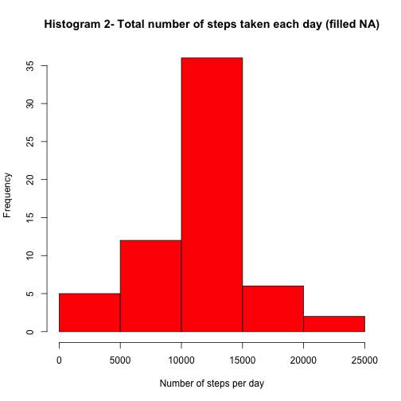

```r
# Histogram with new data without NA
hist(tapply(datafilled$steps, datafilled$date, sum), main = "Histogram 2- Total number of steps taken each day (filled NA)",
    col = "red", xlab = "Number of steps per day")
```

```r
mean(tapply(datafilled$steps, datafilled$date, sum))
```

```
## [1] 10766
```

```r
median(tapply(datafilled$steps, datafilled$date, sum))
```

```
## [1] 10766
```

### Comparative with and without NA

**Histograms**

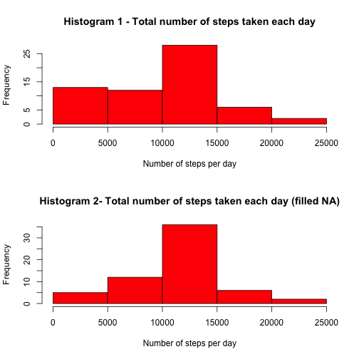

```r
par(mfrow = c(2, 1))
hist(tapply(data$steps, data$date, sum, na.rm = TRUE), main = "Histogram 1 - Total number of steps taken each day",
    col = "red", xlab = "Number of steps per day")
hist(tapply(datafilled$steps, datafilled$date, sum), main = "Histogram 2- Total number of steps taken each day (filled NA)",
    col = "red", xlab = "Number of steps per day")
```

**Change in mean and median**

```r
# With NA
mean(tapply(data$steps, data$date, sum, na.rm = TRUE))
```

```
## [1] 9354
```

```r
median(tapply(data$steps, data$date, sum, na.rm = TRUE))
```

```
## [1] 10395
```

```r
# Without NA
mean(tapply(datafilled$steps, datafilled$date, sum))
```

```
## [1] 10766
```

```r
median(tapply(datafilled$steps, datafilled$date, sum))
```

```
## [1] 10766
```

## Are there differences in activity patterns between weekdays and weekends?

For this part the weekdays() function may be of some help here. Use the dataset with the filled-in missing values for this part.

- Create a new factor variable in the dataset with two levels – “weekday” and “weekend” indicating whether a given date is a weekday or weekend day.

```r
# New variable in dataset with value 'weekday'
datafilled$day = "weekday"
# Change to 'weekend' if date is 'sábado' or 'domingo' (locale Spain)
datafilled$day[weekdays(datafilled$date) == "sábado"] = "weekend"
datafilled$day[weekdays(datafilled$date) == "domingo"] = "weekend"
datafilled$day = as.factor(datafilled$day)
```

Make a panel plot containing a time series plot (i.e. type = “l”) of the 5-minute interval (x-axis) and the average number of steps taken, averaged across all weekday days or weekend days (y-axis).

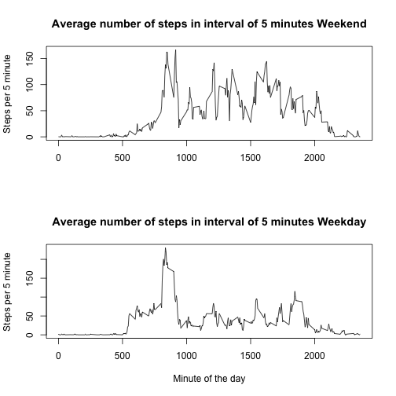

```r
# Calculate of average number of steps taken each 5 minute interval,
# averaged across all weekday days or weekend days
meanweekend = tapply(datafilled$steps[datafilled$day == "weekend"], data$interval[datafilled$day ==
    "weekend"], mean)
meanweekday = tapply(datafilled$steps[datafilled$day == "weekday"], data$interval[datafilled$day ==
    "weekday"], mean)
par(mfrow = c(2, 1))
plot(dimnames(meanweekend)[[1]], meanweekend, type = "l", main = "Average number of steps in interval of 5 minutes Weekend",
    xlab = "", ylab = "Steps per 5 minute")
plot(dimnames(meanweekday)[[1]], meanweekday, type = "l", main = "Average number of steps in interval of 5 minutes Weekday",
    xlab = "Minute of the day", ylab = "Steps per 5 minute")
```

### New version with lattice

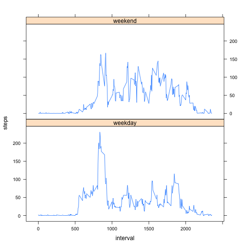

```r
library(lattice)
# build a dataframe
dfweekday = data.frame(interval = as.numeric(dimnames(meanweekday)[[1]]), steps = meanweekday,
    day = "weekday")
dfweekend = data.frame(interval = as.numeric(dimnames(meanweekend)[[1]]), steps = meanweekend,
    day = "weekend")
df = rbind(dfweekday, dfweekend)
xyplot(steps ~ interval | day, data = df, layout = c(1, 2), type = "l")
```